# Etude de la qualité de l’air

Université de Bordeaux - L1 CMI ISI - UE : Projet de statistique

Année 2021-2022

**Nom : URVOAS**  
**Prénom : Olympe**

**Nom : DAMBRINE**  
**Prénom : Lola**

**Nom : DOSSOU**  
**Prénom : Félicia**

**Introduction :** La pollution atmosphérique est l’un des plus grands risques environnementaux pour la santé.

Elle est à l’origine de nombreux accidents vasculaires cérébraux, de cardiopathies, de cancers du poumon et d’affections respiratoires, chroniques ou aiguës, y compris l’asthme.

C’est pourquoi les scientifiques mesurent et étudient la qualité de l’air à différents endroits, à différents moments. Une des mesures de particules fines est le ppm 25.

Le terme « ppm » correspond aux particules fines ayant un diamètre inférieur à 2,5µm (micromètres), soit la taille d’une bactérie. Elles proviennent de l’intérieur de la maison (cuisson, poussière) comme de l’extérieur (transports, industrie).

Actuellement, le taux moyen de ppm25 dans l’atmosphère avoisine les 415 parties par million ce qui signifie qu’il y a 415 molécules de dioxyde de carbone sur 1 million de molécules d’air.

Le diamètre réduit de ces particules favorise la pénétration dans les poumons voire dans le système sanguin.

La valeur de 10 μg/m3 actuellement recommandée par l’OMS a été fixée pour protéger le public des effets du dioxyde d’azote gazeux sur la santé.

Nous allons par la suite nous concentrer sur l’étude de la pollution atmosphérique sur la période du début de l’année 2021, dans différentes grandes villes en Nouvelle-Zélande.

Le pays situé au Sud-Ouest de l’océan Pacifique est composé de 2 îles principales abritant toutes deux des volcans et des glaciers. Si fait de sa localisation ainsi que de son climat, ses taux de pollution sont bien en-dessous des moyennes mondiales.

Avec un total de 10 capteurs en fonction sur l’île, nous allons découvrir les différents taux de pollution dans les grandes villes, en comparaison avec les recommandations mondiales de l’OMS.

**Récupération des données pour le mois de février 2021 et fusion**

```r
library("httr")
library("jsonlite")
data1=read.table("03-05.0.2021.csv", sep=",", header = TRUE)
data2=read.table("06-08.02.2021.csv", sep=",", header = TRUE)
data3=read.table("09-11.02.2021.csv", sep=",", header = TRUE)
data4=read.table("12-14.02.2021.csv", sep=",", header = TRUE)
data5=read.table("15-17.02.2021.csv", sep=",", header = TRUE)
data6=read.table("18-20.02.2021.csv", sep=",", header = TRUE)
data7=read.table("21-23.02.2021.csv", sep=",", header = TRUE)
data8=read.table("24-26.02.2021.csv", sep=",", header = TRUE)
data9=read.table("27-28.02.2021.csv", sep=",", header = TRUE)

mes = rbind(data1,data2,data3,data4,data5,data6,data7,data8,data9)
```

**Visualisation des capteurs sur une carte**

```r
capteurs = unique(mes$location)
length(capteurs) #affiche le nombre de capteurs
```

```
## [1] 10
```

```r
coordonnees = cbind(unique(mes$latitude),unique(mes$longitude))

library(leaflet)
m <- leaflet() %>%
  addTiles() %>%
  addCircleMarkers(lng=coordonnees[,2], lat=coordonnees[,1], popup=capteurs)
m # Affichage de la carte
```

[interactive chart not shown]

**Nombre de mesures, moyenne et variance pour chacun des capteurs**

```r
# tableau nombre de mesures par capteurs
stat_capteurs = data.frame(matrix(0,3,length(capteurs)))
names(stat_capteurs)=capteurs #permet de donner des  noms aux lignes

options("digits" = 5, "scipen" = 0) #réduit le nombre de décimals à 5

for (i in 1:(length(capteurs))) {
  stat_capteurs[1,i]= length(mes$value[mes$location == capteurs[i]])
  stat_capteurs[2,i]= mean(mes$value[mes$location == capteurs[i]])
  stat_capteurs[3,i]= var(mes$value[mes$location == capteurs[i]])
}
rownames(stat_capteurs)[1]="Nombre de mesures"
rownames(stat_capteurs)[2]="Moyenne"
rownames(stat_capteurs)[3]="Variance"
#Nous venons de donner un nom aux lignes

stat_capteurs
```

|  | Outside | Browns Bay New Zealand | Central School | Brooklyn 1 | Waikanae New Zealand | DataIsEpic2020GreendaleNZ | Linton | Cashmere, Christchurch | Camp Glenorchy | Ruatoria PA |
| --- | --- | --- | --- | --- | --- | --- | --- | --- | --- | --- |
| Nombre de mesures | 10562.0000 | 11499.0000 | 11781.0000 | 11612.0000 | 11099.0000 | 5577.0000 | 9137.0000 | 10337.0000 | 9397.00000 | 9.000000 |
| Moyenne | 1.8802 | 1.6480 | 1.8078 | 1.2855 | 1.5024 | 2.1818 | 1.4250 | 3.3902 | 0.67424 | 0.622222 |
| Variance | 4.7988 | 5.0165 | 4.6814 | 3.0314 | 4.2071 | 4.9775 | 5.0551 | 24.1392 | 4.21901 | 0.016944 |

**Représentation de certaines valeurs statistiques sur une carte**

```r
values = as.numeric(stat_capteurs[2,])

pal <- colorNumeric(
  palette = colorRampPalette(c('green', 'red'))(length(values)),
  domain = values)

m <- leaflet() %>%
  addTiles() %>%
  addCircleMarkers(
    lng =  coordonnees[,2],
    lat =  coordonnees[,1],
    radius = 3*as.numeric(abs(values)),
    color =  pal(values),
    opacity = 0.9,
    popup = capteurs)%>%
  addLegend(
    "bottomleft", pal = colorNumeric(palette=colorRampPalette(c('green','red'))(length(values)),
  domain = values),
  values = values, title="Taux de pm25",
  opacity = 0.9)
m  # Affichage de la carte
```

[interactive chart not shown]

**Temps où sont faits les mesures**

```r
temps = unique(mes$utc)
print(temps[1]) #On visualise le format d'un temps
```

```
## [1] "2021-02-04T22:59:57+00:00"
```

```r
length(temps) #Nombre de temps d'enregistrement différents
```

```
## [1] 87721
```

```r
temps1 = mes$utc[mes$location==capteurs[1]]
temps2 = mes$utc[mes$location==capteurs[2]]
```

**Affichage des données pour le capteur numéro 10 et à l’heure numéro 20 par exemple**

```r
capteurs[10]
```

```
## [1] "Ruatoria PA"
```

```r
temps[20]
```

```
## [1] "2021-02-04T22:55:38+00:00"
```

```r
mes$value[(mes$location==capteurs[10]) & (mes$utc==temps[20])]
```

```
## numeric(0)
```

**Construction de la matrice des données, avec en colonnes les capteurs, en ligne les temps d’enregistrement**  
L’entrée (i,j) de X est la valeur mesurée de concentration en pm25 à l’heure numéro i et le capteur numéro j.

```r
X = matrix(0,length(temps),length(capteurs))

for (i in 1:length(temps)) {
  for (j in 1:length(capteurs)) {
    X[i,j] = mean(as.numeric(mes$value[(mes$location==capteurs[j]) & (mes$utc==temps[i])]))
  }
}
```

**Affichage des données pour le capteur numéro 1**

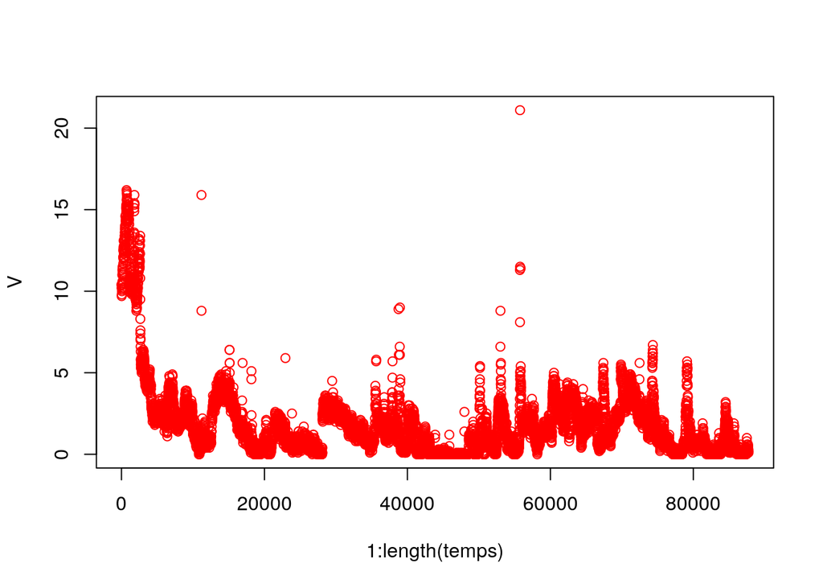

```r
V = X[,1]
plot(1:length(temps),V,'p',col="red")
```

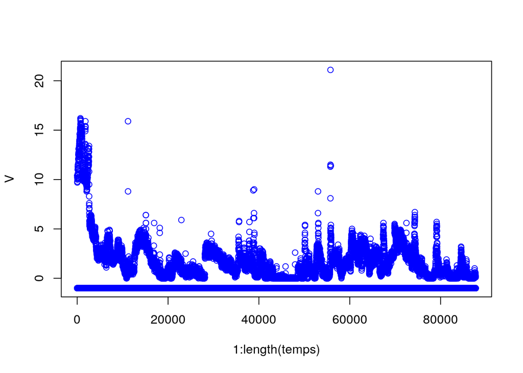

```r
V[is.nan(V)] = -1
plot(1:length(temps),V,'p',col="blue")
```

**Convertion en objet temps**

```r
strptime(temps[1],format = "%Y-%m-%dT%H:%M:%S")
```

```
## [1] "2021-02-04 22:59:57 CET"
```

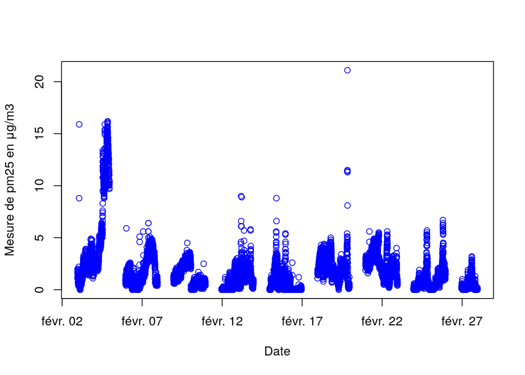

```r
temps_converti = strptime(temps[1:length(temps)],format = "%Y-%m-%dT%H:%M:%S")

V = X[,1]
plot(temps_converti,V,'p',col="blue",xlab="Date",ylab="Mesure de pm25 en μg/m3")
```

Pour les PM2,5, il n’y a pas de réglementation. L’Union européenne a fixé son objectif de qualité à 20μg/m3 en moyenne sur l’année. Le Grenelle de l’environnement souhaitait arriver à 15μg/m3. L’Organisation Mondiale de la Santé recommande, elle, une valeur de 10 μg/m3.

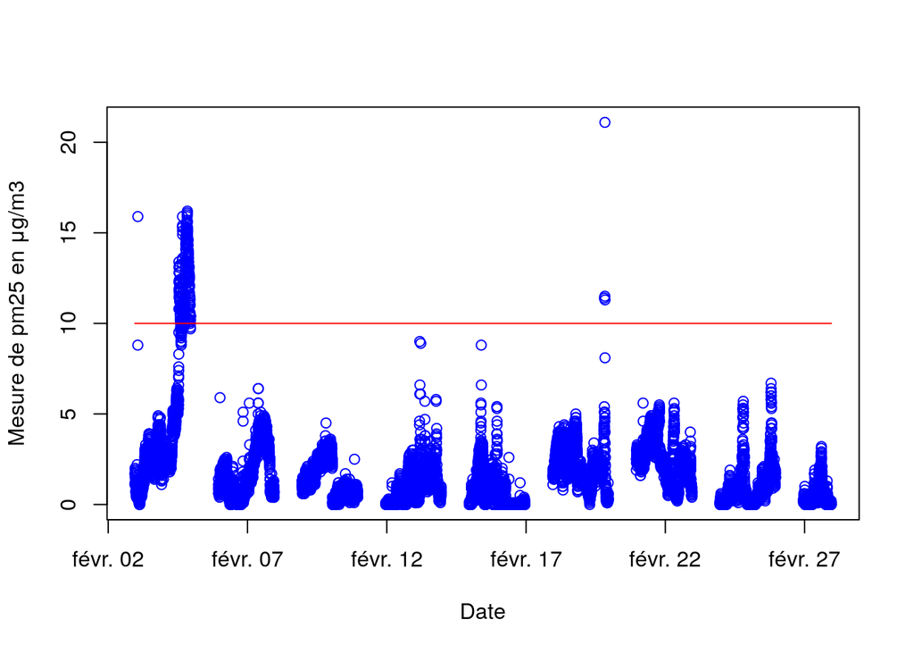

```r
seuil = 10 #recommendation de l'OMS
plot(temps_converti,V,'p',col="blue",xlab="Date",ylab="Mesure de pm25 en μg/m3")
lines(temps_converti,seuil*rep(1,length(temps_converti)),col="red")
```

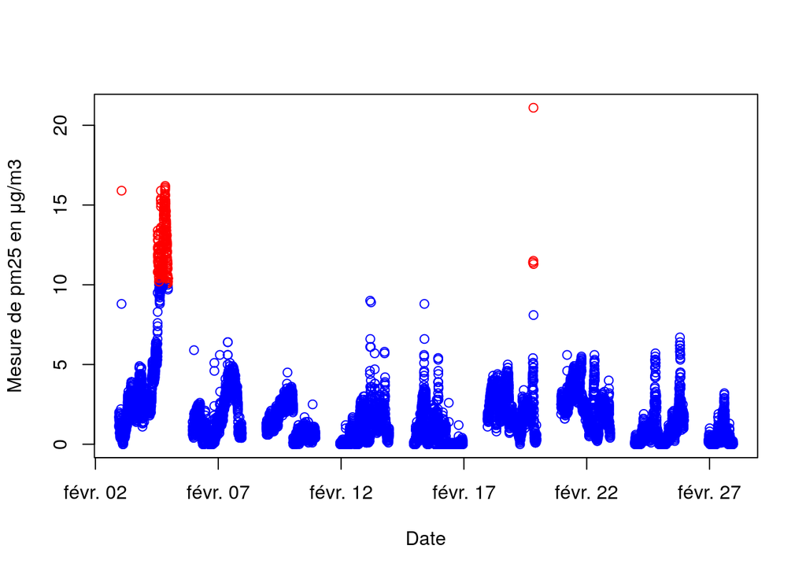

```r
V = X[,1]
couleur = rep("blue",length(temps_converti))
couleur[V > seuil] = "red"
plot(temps_converti,V,'p',col=couleur,xlab="Date",ylab="Mesure de pm25 en μg/m3")
```

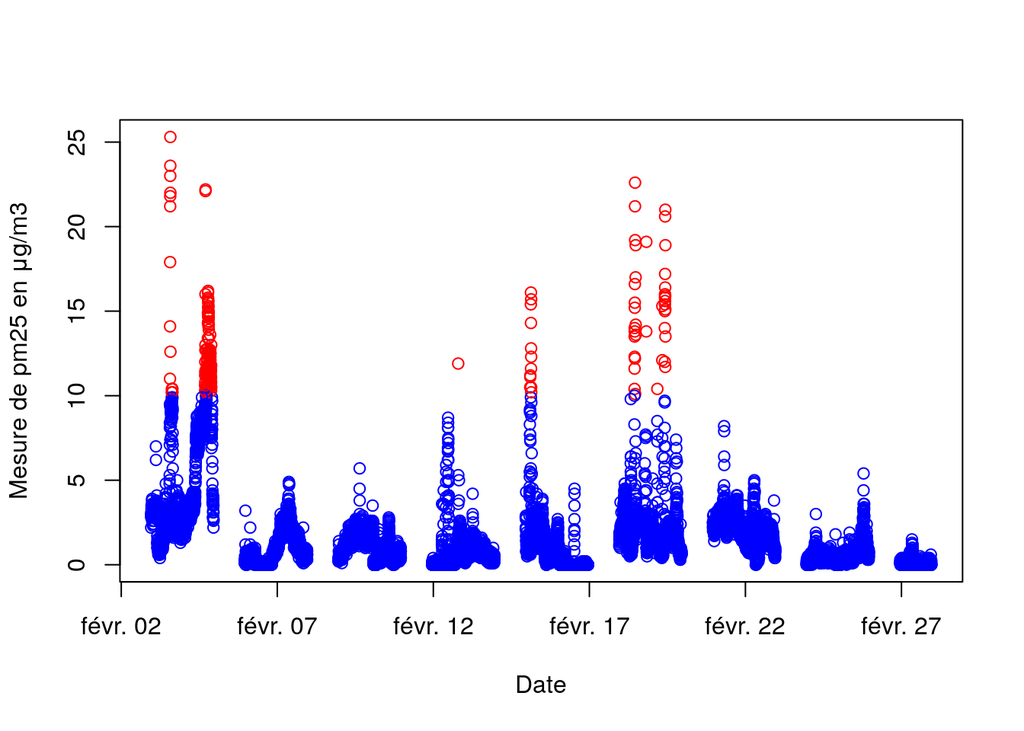

```r
V = X[,2]
couleur = rep("blue",length(temps_converti))
couleur[V > seuil] = "red"
plot(temps_converti,V,'p',col=couleur,xlab="Date",ylab="Mesure de pm25 en μg/m3")
```

```r
library(corrplot)
```

**Visualisation des corrélations**

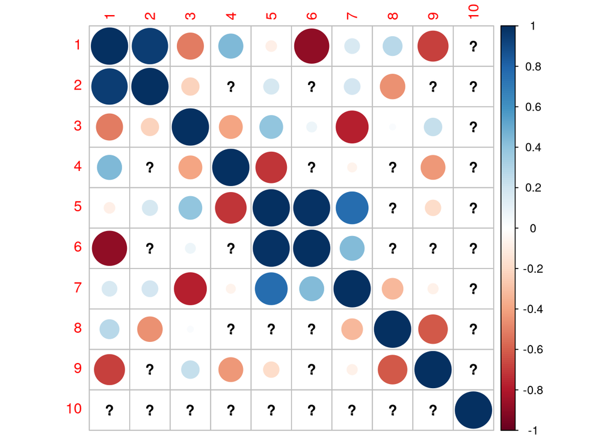

```r
corrplot(corX)
```

**Représenter une station et ses corrélations avec les autres par un code couleur proportionnel au niveau de cette corrélation**

```r
N = length(corX[1,])
values = corX[1,]
pal <- colorNumeric(
  palette = colorRampPalette(c('red', 'blue'))(length(values)),
  domain = values)

m <- leaflet() %>%
  addTiles() %>%
  addCircleMarkers(
    lng =  coordonnees[,2],
    lat =  coordonnees[,1],
    radius = 15*as.numeric(abs(values)),
    color =  c('black',pal(values[2:N])),
    opacity = 0.9
  )%>%
  addLegend(
    "bottomleft", pal = colorNumeric(palette=colorRampPalette(c('red','green'))(length(values)),
  domain = values),
  values = values, title="Niveau de corrélation",
  opacity = 0.9)
m  # Affichage de la carte
```

[interactive chart not shown]

**Détermination des capteurs aux taux moyens de pm25 minimum et maximum**

```r
PosMax = which.max(stat_capteurs[2,])
x1=mes$latitude[mes$location==capteurs[PosMax]]
x1=x1[1]
y1=mes$longitude[mes$location==capteurs[PosMax]]
y1=y1[1]

PosMin = which.min(stat_capteurs[2,])
x2=mes$latitude[mes$location==capteurs[PosMin]]
x2=x2[1]
y2=mes$longitude[mes$location==capteurs[PosMin]]
y2=y2[1]

Pos=c(PosMax,PosMin)

lat = c(x1, x2)
lng = c(y1, y2)
coordonnees2=cbind(lat,lng)
```

**Affichage sur une carte de ces capteurs**

```r
values = as.numeric(stat_capteurs[2,])

pal <- colorNumeric(
  palette = colorRampPalette(c('red', 'green'))(length(values)),
  domain = values)

leaflet(data = coordonnees2) %>% addTiles() %>%addCircleMarkers(lng=coordonnees2[,2],
lat=coordonnees2[,1],
    radius = 5*as.numeric(abs(values)),
    color =  pal(values),
    opacity = 0.9,
popup=paste("<b>Lieu:</b>",capteurs[Pos],"<br>","<b>pm25:</b>",stat_capteurs[2,][Pos]))
```

[interactive chart not shown]

**Etude des villes où se trouvent ces capteurs**

**Cashmere, Christchurch**

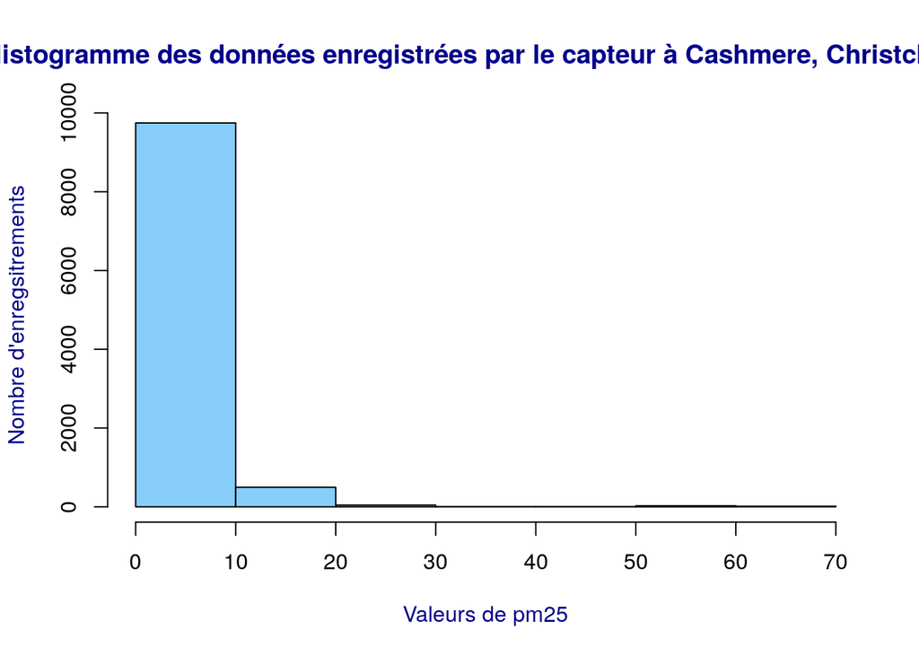

```r
hist(mes$value[mes$location=="Cashmere, Christchurch"],
     col="lightskyblue",
     main="Histogramme des données enregistrées par le capteur à Cashmere, Christchurch",
     col.main="darkblue",
     xlab="Valeurs de pm25",
     col.lab="darkblue",
     ylab="Nombre d'enregsitrements",
     breaks=5)
```

**Ruatoria**

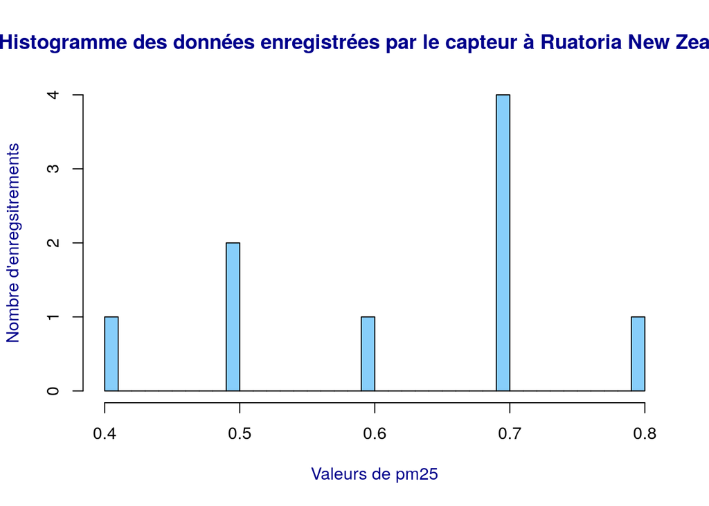

```r
hist(mes$value[mes$location=="Ruatoria PA"],
     col="lightskyblue",
     main="Histogramme des données enregistrées par le capteur à Ruatoria New Zealand",
     col.main="darkblue",
     xlab="Valeurs de pm25",
     col.lab="darkblue",
     ylab="Nombre d'enregsitrements",
     breaks=30)
```

**Conclusion:**

La Nouvelle-Zélande connaît un niveau relativement bas de pollution de l’ air par rapport à de nombreux autres pays.

Cela s’explique par sa géolocalisation. Le pays a un climat tempéré avec des précipitations assez importantes et de nombreuses heures d’ensoleillement. De plus, il s’agit d’une île. Les îles, notamment les plus éloignées du continent terrestre, sont naturellement protégées des nuisances modernes par leur insularité. De plus, le pays est plus que fidèle à son engagement environnemental: la Nouvelle-Zélande connaît une forte progression de son parc d’énergie renouvelable, notamment grâce à ses ressources géothermiques. En effet, selon le dernier rapport du ministère néo-zélandais du Commerce, de l’Innovation et de l’Emploi, les sources renouvelables ont contribué à hauteur de 79,9% à la production totale d’électricité du pays.

Une autre problématique sur laquelle nous nous sommes penchées est l’impact qu’ont eu les incendies d’Australie en 2020 sur la pollution atmosphérique en Nouvelle-Zélande.

Il y a deux ans, en juin 2019, avait débuté la saison des feux de brousse en Australie, qui s’est achevée en mars 2020. La qualité de l’air a souvent atteint des niveaux dangereux, justifiant l’état d’urgence dans de nombreuses villes. Par exemple, en décembre, la pollution en Australie était onze fois au-dessus du seuil limite.

Nous nous sommes demandé si l’intensité et l’étendue de ces feux ont atteint les îles voisines, notamment la Nouvelle-Zélande dont les cités se situent à environ 2000 kilomètres au-delà de la mer Tasman.

La fumée des incendies de forêts en Australie a donc atteint la Nouvelle-Zélande, située à des milliers de kilomètres, et des glaciers habituellement blancs ont pris une nuance de couleur caramel, selon les services météo et des témoignages sur les réseaux sociaux.

Malheureusement nous n’avons pas pu réaliser de comparaison car les données de qualité de l’air pour la période de ces feux(2019-2020) n’étaient pas disponibles sur cette période (les fichiers qu’on a pu télécharger étaient vides).

Cependant on a pu trouver une carte et un article publié sur le site du ministère de la santé néo-zélandais (https://www.health.govt.nz/news-media/news-items/ministry-health-monitoring-air-quality-following-australian-bushfires ) qui montrent bien que les taux de pm25 ont augmenté sur la période des feux en Australie.